# COD_week12_2_MGK_BTE3207

Minsik Kim

2023-11-15

# Analysis of variance

## Before begin..

Let’s load the SBP dataset.

```r
dataset_sbp <- read.csv(file = "/Users/minsikkim/Dropbox (Personal)/Inha/5_Lectures/Advanced biostatistics/scripts/BTE3207_Advanced_Biostatistics/dataset/sbp_dataset_korea_2013-2014.csv")



head(dataset_sbp)
```

```
##   SEX BTH_G SBP DBP FBS DIS  BMI
## 1   1     1 116  78  94   4 16.6
## 2   1     1 100  60  79   4 22.3
## 3   1     1 100  60  87   4 21.9
## 4   1     1 111  70  72   4 20.2
## 5   1     1 120  80  98   4 20.0
## 6   1     1 115  79  95   4 23.1
```

Making a new variable `hypertension`

```r
dataset_sbp$hypertension <- ifelse(dataset_sbp$SBP > 130 |
                                           dataset_sbp$DBP > 80,
                                   T,
                                   F)


dataset_sbp$history_of_hypertension <- ifelse(dataset_sbp$DIS == 1 |
                                           dataset_sbp$DIS == 2,
                                   T,
                                   F)

dataset_sbp$DIS <- factor(dataset_sbp$DIS,
                          levels = c(1,2,3,4),
                          labels = c("Hypertension and diabetes",
                                     "Hypertension",
                                     "Diabetes",
                                     "No history"))

set.seed(1)

dataset_sbp_small <- subset(dataset_sbp, row.names(dataset_sbp) %in% sample(x = 1:1000000, size = 1000))
```

## DIS groups

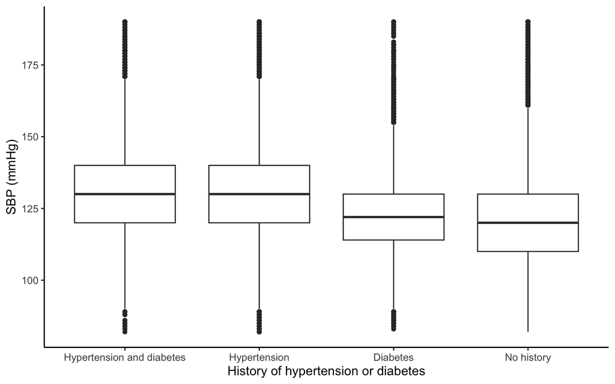

```r
ggplot(dataset_sbp, aes(y = SBP, x = DIS)) +
        geom_boxplot() +
        xlab("History of hypertension or diabetes") +
        ylab("SBP (mmHg)") +
        theme_classic(base_size = 12)
```

# T-test?

DIS group 1 vs 4

```r
t.test(dataset_sbp %>% filter(as.numeric(DIS) == 1) %>% .$SBP,
       dataset_sbp %>% filter(as.numeric(DIS) == 4) %>% .$SBP,
       var.equal = F)
```

```
##
##  Welch Two Sample t-test
##
## data:  dataset_sbp %>% filter(as.numeric(DIS) == 1) %>% .$SBP and dataset_sbp %>% filter(as.numeric(DIS) == 4) %>% .$SBP
## t = 169.59, df = 59802, p-value < 2.2e-16
## alternative hypothesis: true difference in means is not equal to 0
## 95 percent confidence interval:
##  11.18067 11.44213
## sample estimates:
## mean of x mean of y
##  130.5640  119.2526
```

DIS group 2 vs 4

```r
t.test(dataset_sbp %>% filter(as.numeric(DIS) == 2) %>% .$SBP,
       dataset_sbp %>% filter(as.numeric(DIS) == 4) %>% .$SBP,
       var.equal = F)
```

```
##
##  Welch Two Sample t-test
##
## data:  dataset_sbp %>% filter(as.numeric(DIS) == 2) %>% .$SBP and dataset_sbp %>% filter(as.numeric(DIS) == 4) %>% .$SBP
## t = 282.46, df = 225561, p-value < 2.2e-16
## alternative hypothesis: true difference in means is not equal to 0
## 95 percent confidence interval:
##  11.22032 11.37713
## sample estimates:
## mean of x mean of y
##  130.5513  119.2526
```

DIS group 3 vs 4

```r
t.test(dataset_sbp %>% filter(as.numeric(DIS) == 3) %>% .$SBP,
       dataset_sbp %>% filter(as.numeric(DIS) == 4) %>% .$SBP,
       var.equal = F)
```

```
##
##  Welch Two Sample t-test
##
## data:  dataset_sbp %>% filter(as.numeric(DIS) == 3) %>% .$SBP and dataset_sbp %>% filter(as.numeric(DIS) == 4) %>% .$SBP
## t = 60.351, df = 48165, p-value < 2.2e-16
## alternative hypothesis: true difference in means is not equal to 0
## 95 percent confidence interval:
##  3.937403 4.201738
## sample estimates:
## mean of x mean of y
##  123.3221  119.2526
```

DIS group 1 vs 2

```r
t.test(dataset_sbp %>% filter(as.numeric(DIS) == 1) %>% .$SBP,
       dataset_sbp %>% filter(as.numeric(DIS) == 2) %>% .$SBP,
       var.equal = F)
```

```
##
##  Welch Two Sample t-test
##
## data:  dataset_sbp %>% filter(as.numeric(DIS) == 1) %>% .$SBP and dataset_sbp %>% filter(as.numeric(DIS) == 2) %>% .$SBP
## t = 0.16998, df = 90286, p-value = 0.865
## alternative hypothesis: true difference in means is not equal to 0
## 95 percent confidence interval:
##  -0.1334474  0.1587919
## sample estimates:
## mean of x mean of y
##  130.5640  130.5513
```

….

Do you think it is reasonable?

# Linear model?

```r
lm(data = dataset_sbp, SBP ~ DIS) %>%
        summary
```

```
##
## Call:
## lm(formula = SBP ~ DIS, data = dataset_sbp)
##
## Residuals:
##     Min      1Q  Median      3Q     Max
## -48.564  -9.253  -0.253   9.747  70.747
##
## Coefficients:
##                  Estimate Std. Error  t value Pr(>|t|)
## (Intercept)     130.56397    0.05974 2185.532   <2e-16 ***
## DISHypertension  -0.01267    0.06884   -0.184    0.854
## DISDiabetes      -7.24183    0.08938  -81.022   <2e-16 ***
## DISNo history   -11.31140    0.06186 -182.866   <2e-16 ***
## ---
## Signif. codes:  0 '***' 0.001 '**' 0.01 '*' 0.05 '.' 0.1 ' ' 1
##
## Residual standard error: 13.8 on 999996 degrees of freedom
## Multiple R-squared:  0.1013, Adjusted R-squared:  0.1013
## F-statistic: 3.756e+04 on 3 and 999996 DF,  p-value: < 2.2e-16
```

It shows how different whether the group difference estimates with beta values (as well as CIs and p-values).

But can we assess wheter the `DIS` is a significant factor affecting SBP?

Here comes the analysis of variance.

# Analysis of variance

Let’s say we are comparing multipel groups

Making a new dataset

```r
midterm <- data.frame(midterm = c(82, 83, 97, 83, 78, 68, 38, 59, 55),
           major = rep(c("BE", "MBE", "CHEM"), times=1, each=3))
```

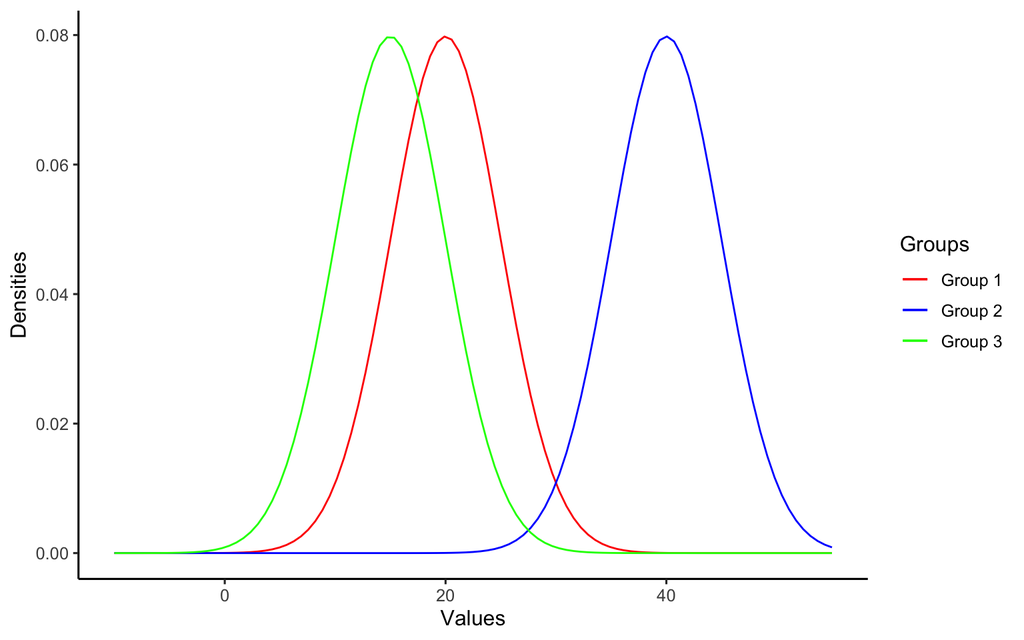

```r
mean_sim <- 10
std_sim <- 5

lcb <- ((mean_sim - (3 * std_sim)) - 5)
ucb <- (((2 * mean_sim) + (3 * (2 * std_sim))) + 5)

ggplot(data = data.frame(u = c(lcb, ucb)),
       mapping = aes(x = u)) +
  stat_function(mapping = aes(colour = "Group 1"),
                fun = dnorm,
                args = list(mean = 20,
                            sd = std_sim)) +
  stat_function(mapping = aes(colour = "Group 2"),
                fun = dnorm,
                args = list(mean = 40,
                            sd = (std_sim))) +
        stat_function(mapping = aes(colour = "Group 3"),
                fun = dnorm,
                args = list(mean = 15,
                            sd = (std_sim))) +
  scale_colour_manual(values = c("red", "blue", "green")) +
  labs(x = "Values",
       y = "Densities",
       col = "Groups") +
        theme_classic(base_size = 12)
```

Variance of *group means*

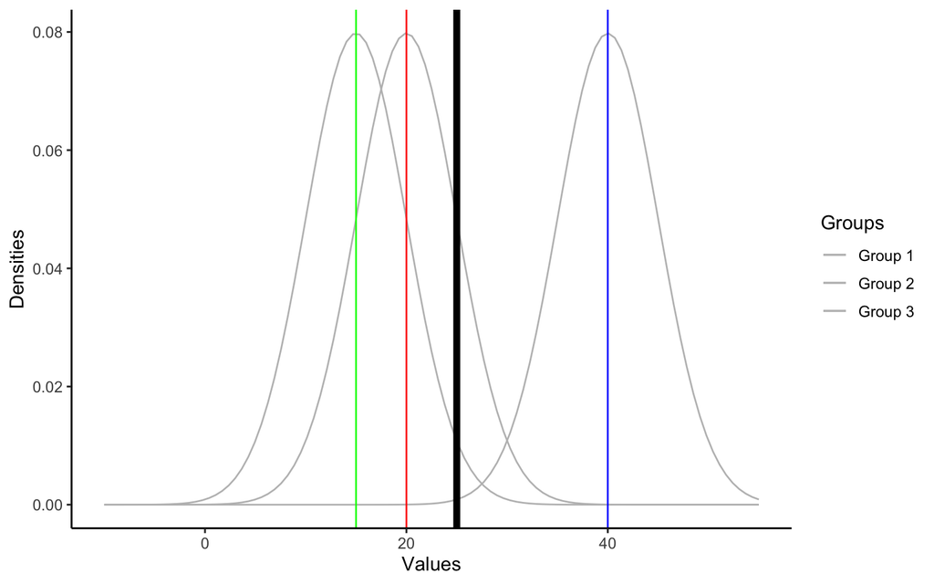

```r
mean_sim <- 10
std_sim <- 5

lcb <- ((mean_sim - (3 * std_sim)) - 5)
ucb <- (((2 * mean_sim) + (3 * (2 * std_sim))) + 5)

ggplot(data = data.frame(u = c(lcb, ucb)),
       mapping = aes(x = u)) +
  stat_function(mapping = aes(colour = "Group 1"),
                fun = dnorm,
                args = list(mean = 20,
                            sd = std_sim)) +
  stat_function(mapping = aes(colour = "Group 2"),
                fun = dnorm,
                args = list(mean = 40,
                            sd = (std_sim))) +
        stat_function(mapping = aes(colour = "Group 3"),
                fun = dnorm,
                args = list(mean = 15,
                            sd = (std_sim))) +
        geom_vline(xintercept = c(20, 40, 15), color= c("red", "blue", "green")) +
        scale_colour_manual(values = c("grey", "grey", "grey")) +
        geom_vline(xintercept = mean(c(15, 40, 20)), col = "Black", size = 2) +
  labs(x = "Values",
       y = "Densities",
       col = "Groups") +
        theme_classic(base_size = 12)
```

# Uncertainty - variance within groups

## with smaller variance within group

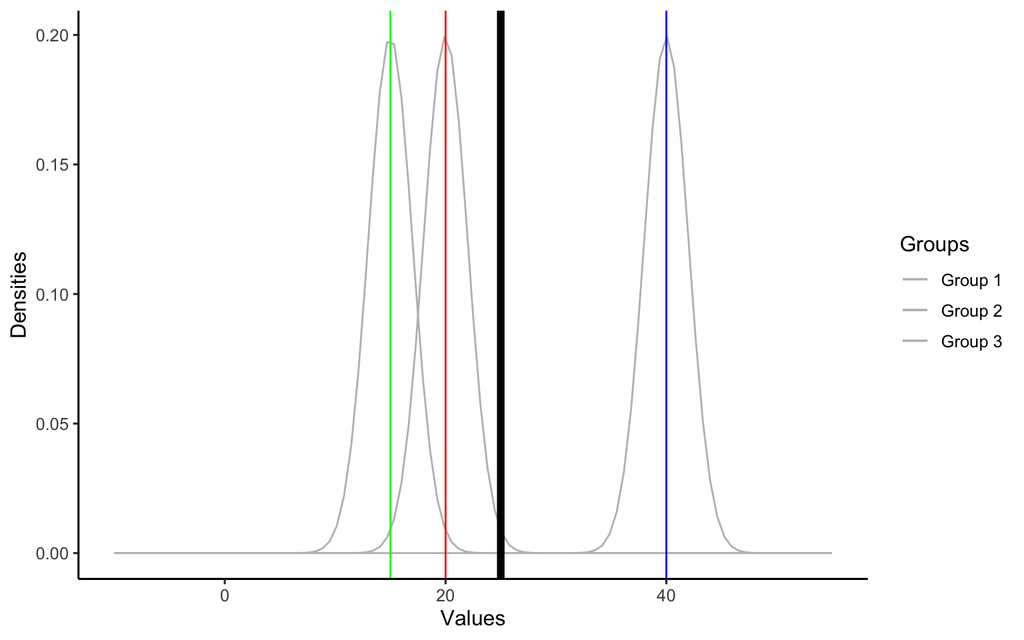

```r
mean_sim <- 10
std_sim <- 5

lcb <- ((mean_sim - (3 * std_sim)) - 5)
ucb <- (((2 * mean_sim) + (3 * (2 * std_sim))) + 5)

ggplot(data = data.frame(u = c(lcb, ucb)),
       mapping = aes(x = u)) +
  stat_function(mapping = aes(colour = "Group 1"),
                fun = dnorm,
                args = list(mean = 20,
                            sd = 0.4*std_sim)) +
  stat_function(mapping = aes(colour = "Group 2"),
                fun = dnorm,
                args = list(mean = 40,
                            sd = 0.4*(std_sim))) +
        stat_function(mapping = aes(colour = "Group 3"),
                fun = dnorm,
                args = list(mean = 15,
                            sd = 0.4*(std_sim))) +
        geom_vline(xintercept = c(20, 40, 15), color= c("red", "blue", "green")) +
        scale_colour_manual(values = c("grey", "grey", "grey")) +
        geom_vline(xintercept = mean(c(15, 40, 20)), col = "Black", size = 2) +
  labs(x = "Values",
       y = "Densities",
       col = "Groups") +
        theme_classic(base_size = 12)
```

## Extremely smalle variance

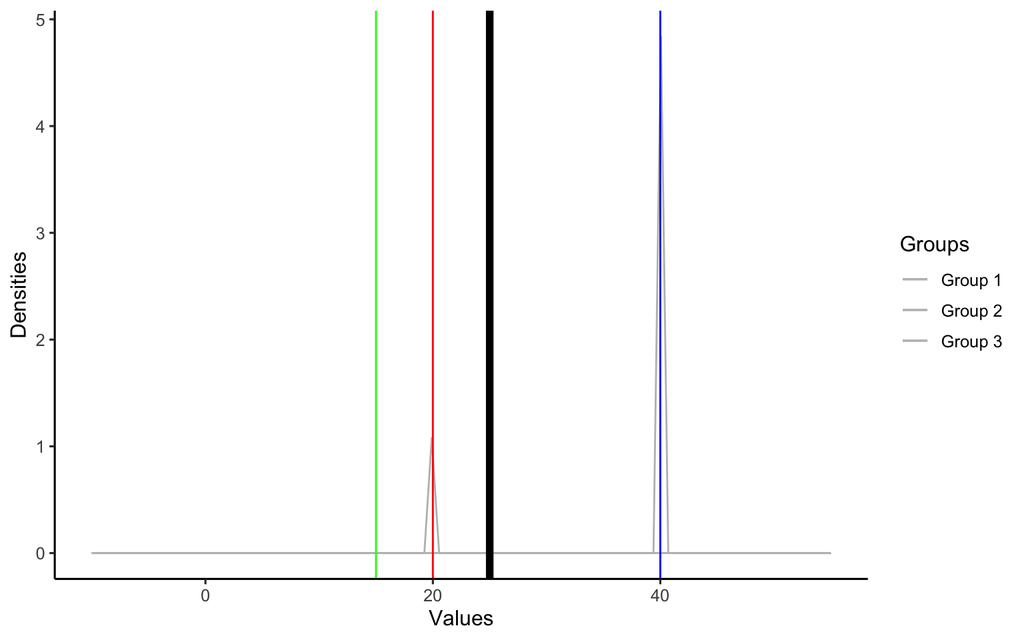

```r
mean_sim <- 10
std_sim <- 5

lcb <- ((mean_sim - (3 * std_sim)) - 5)
ucb <- (((2 * mean_sim) + (3 * (2 * std_sim))) + 5)

ggplot(data = data.frame(u = c(lcb, ucb)),
       mapping = aes(x = u)) +
  stat_function(mapping = aes(colour = "Group 1"),
                fun = dnorm,
                args = list(mean = 20,
                            sd = 0.01*std_sim)) +
  stat_function(mapping = aes(colour = "Group 2"),
                fun = dnorm,
                args = list(mean = 40,
                            sd = 0.01*(std_sim))) +
        stat_function(mapping = aes(colour = "Group 3"),
                fun = dnorm,
                args = list(mean = 15,
                            sd = 0.01*(std_sim))) +
        geom_vline(xintercept = c(20, 40, 15), color= c("red", "blue", "green")) +
        scale_colour_manual(values = c("grey", "grey", "grey")) +
        geom_vline(xintercept = mean(c(15, 40, 20)), col = "Black", size = 2) +
  labs(x = "Values",
       y = "Densities",
       col = "Groups") +
        theme_classic(base_size = 12)
```

With extremly high sd

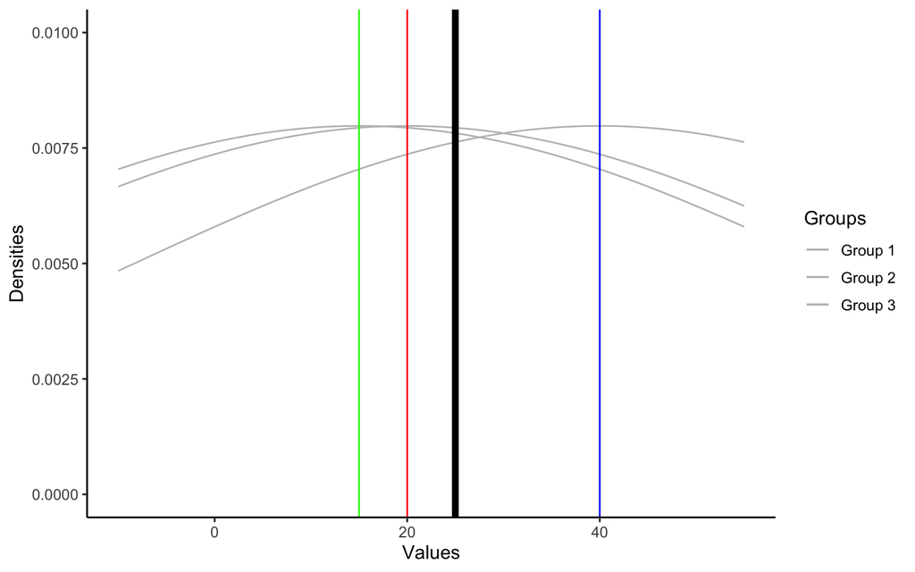

```r
mean_sim <- 10
std_sim <- 5

lcb <- ((mean_sim - (3 * std_sim)) - 5)
ucb <- (((2 * mean_sim) + (3 * (2 * std_sim))) + 5)

ggplot(data = data.frame(u = c(lcb, ucb)),
       mapping = aes(x = u)) +
  stat_function(mapping = aes(colour = "Group 1"),
                fun = dnorm,
                args = list(mean = 20,
                            sd = 10*std_sim)) +
  stat_function(mapping = aes(colour = "Group 2"),
                fun = dnorm,
                args = list(mean = 40,
                            sd = 10*(std_sim))) +
        stat_function(mapping = aes(colour = "Group 3"),
                fun = dnorm,
                args = list(mean = 15,
                            sd = 10*(std_sim))) +
        geom_vline(xintercept = c(20, 40, 15), color= c("red", "blue", "green")) +
        scale_colour_manual(values = c("grey", "grey", "grey")) +
        geom_vline(xintercept = mean(c(15, 40, 20)), col = "Black", size = 2) +
        ylim(c(0,0.01)) +
  labs(x = "Values",
       y = "Densities",
       col = "Groups") +
        theme_classic(base_size = 12)
```

Looking at extremecases clearifies what analysis of variance is testing.

## Midterm dataset

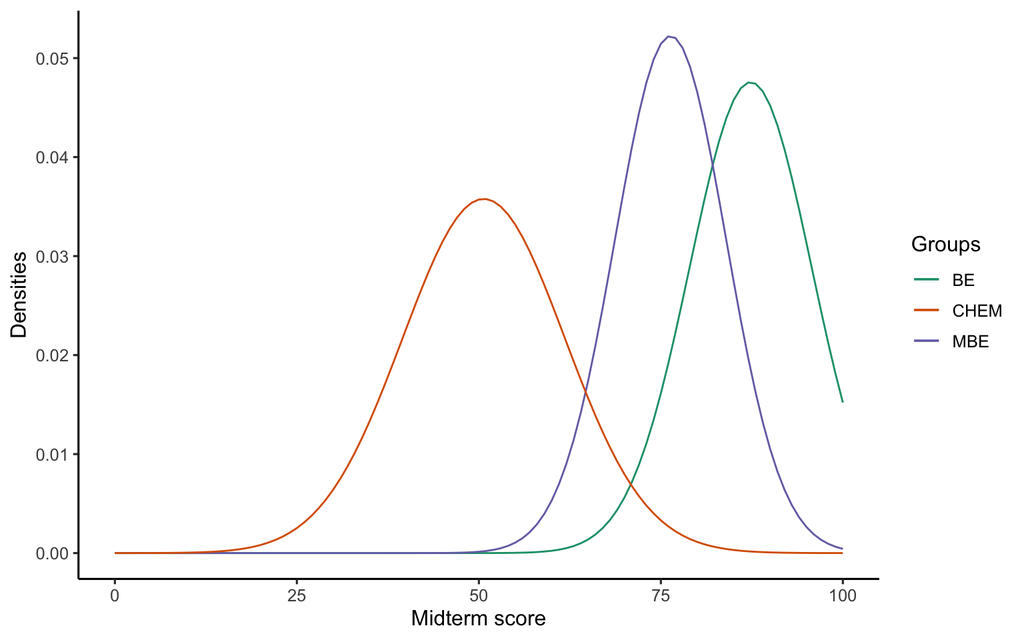

```r
ggplot(data = midterm) +
  stat_function(mapping = aes(colour = "BE"),
                fun = dnorm,
                args = list(mean = midterm %>% filter(major == "BE") %>% .$midterm %>% mean,
                            sd = midterm %>% filter(major == "BE") %>% .$midterm %>% sd)) +
  stat_function(mapping = aes(colour = "MBE"),
                fun = dnorm,
                args = list(mean = midterm %>% filter(major == "MBE") %>% .$midterm %>% mean,
                            sd = midterm %>% filter(major == "MBE") %>% .$midterm %>% sd)) +
        stat_function(mapping = aes(colour = "CHEM"),
                fun = dnorm,
                args = list(mean = midterm %>% filter(major == "CHEM") %>% .$midterm %>% mean,
                            sd = midterm %>% filter(major == "CHEM") %>% .$midterm %>% sd)) +
  scale_color_brewer(type = "qual", palette = 2) +
        xlim(c(0, 100)) +
  labs(x = "Midterm score",
       y = "Densities",
       col = "Groups") +
        theme_classic(base_size = 12)
```

## SBP dataset

In histogram, the data can be shown as

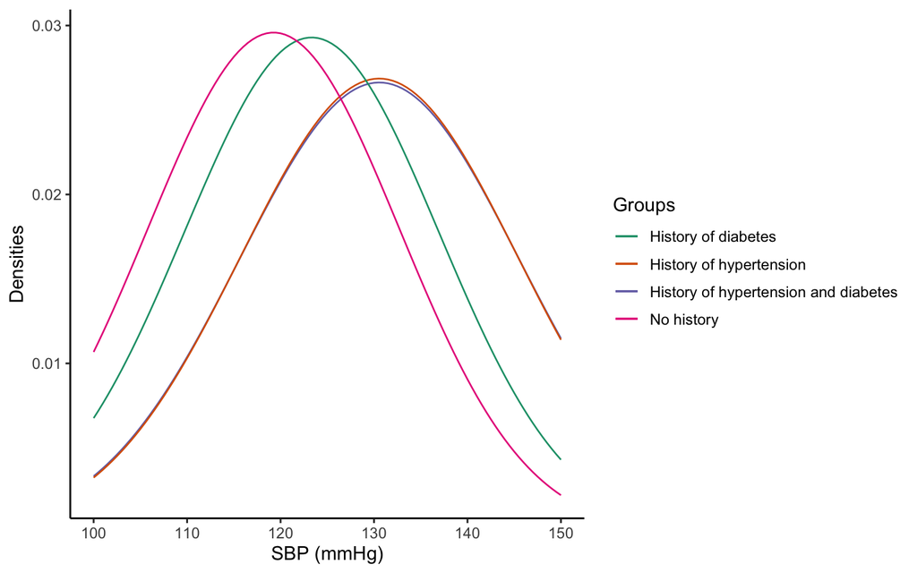

```r
ggplot(data = dataset_sbp) +
  stat_function(mapping = aes(colour = "History of hypertension and diabetes"),
                fun = dnorm,
                args = list(mean = dataset_sbp %>% filter(as.numeric(DIS) == 1) %>% .$SBP %>% mean,
                            sd = dataset_sbp %>% filter(as.numeric(DIS) == 1) %>% .$SBP %>% sd)) +
  stat_function(mapping = aes(colour = "History of hypertension"),
                fun = dnorm,
                args = list(mean = dataset_sbp %>% filter(as.numeric(DIS) == 2) %>% .$SBP %>% mean,
                            sd = dataset_sbp %>% filter(as.numeric(DIS) == 2) %>% .$SBP %>% sd)) +
        stat_function(mapping = aes(colour = "History of diabetes"),
                fun = dnorm,
                args = list(mean = dataset_sbp %>% filter(as.numeric(DIS) == 3) %>% .$SBP %>% mean,
                            sd = dataset_sbp %>% filter(as.numeric(DIS) == 3) %>% .$SBP %>% sd)) +
        stat_function(mapping = aes(colour = "No history"),
                fun = dnorm,
                args = list(mean = dataset_sbp %>% filter(as.numeric(DIS) == 4) %>% .$SBP %>% mean,
                            sd = dataset_sbp %>% filter(as.numeric(DIS) == 4) %>% .$SBP %>% sd)) +
  scale_color_brewer(type = "qual", palette = 2) +
        xlim(c(100,150)) +
  labs(x = "SBP (mmHg)",
       y = "Densities",
       col = "Groups") +
        theme_classic(base_size = 12)
```

# ANOVA in R

`aov()` function can calculate the result of analysis of variance

```r
aov(midterm ~ major, data = midterm) %>%
        summary
```

```
##             Df Sum Sq Mean Sq F value  Pr(>F)
## major        2   2124  1062.1   12.59 0.00712 **
## Residuals    6    506    84.3
## ---
## Signif. codes:  0 '***' 0.001 '**' 0.01 '*' 0.05 '.' 0.1 ' ' 1
```

```r
aov(SBP ~ DIS, data = dataset_sbp_small) %>%
        summary
```

```
##              Df Sum Sq Mean Sq F value Pr(>F)
## DIS           3  29932    9977   53.54 <2e-16 ***
## Residuals   996 185607     186
## ---
## Signif. codes:  0 '***' 0.001 '**' 0.01 '*' 0.05 '.' 0.1 ' ' 1
```

Else, we can implement anova into effect modifications

```r
aov(SBP ~ SEX + BTH_G * BMI + FBS + DIS * DBP, data = dataset_sbp_small) %>%
        summary
```

```
##              Df Sum Sq Mean Sq  F value   Pr(>F)
## SEX           1   6475    6475   82.630  < 2e-16 ***
## BTH_G         1  23618   23618  301.394  < 2e-16 ***
## BMI           1  10826   10826  138.150  < 2e-16 ***
## FBS           1   2905    2905   37.073 1.63e-09 ***
## DIS           3   8318    2773   35.383  < 2e-16 ***
## DBP           1  85682   85682 1093.431  < 2e-16 ***
## BTH_G:BMI     1      0       0    0.000    0.985
## DIS:DBP       3    374     125    1.593    0.190
## Residuals   987  77342      78
## ---
## Signif. codes:  0 '***' 0.001 '**' 0.01 '*' 0.05 '.' 0.1 ' ' 1
```

```r
lm(SBP ~ SEX + BTH_G * BMI + FBS + DIS * DBP, data = dataset_sbp_small) %>%
        summary
```

```
##
## Call:
## lm(formula = SBP ~ SEX + BTH_G * BMI + FBS + DIS * DBP, data = dataset_sbp_small)
##
## Residuals:
##     Min      1Q  Median      3Q     Max
## -25.193  -5.601  -0.520   5.510  38.301
##
## Coefficients:
##                       Estimate Std. Error t value Pr(>|t|)
## (Intercept)          49.345205  11.941720   4.132 3.90e-05 ***
## SEX                  -0.976183   0.589594  -1.656   0.0981 .
## BTH_G                 0.256344   0.292661   0.876   0.3813
## BMI                   0.245572   0.187394   1.310   0.1903
## FBS                   0.019089   0.012977   1.471   0.1416
## DISHypertension      -4.553308  12.265896  -0.371   0.7106
## DISDiabetes          -1.391342  17.500850  -0.080   0.9366
## DISNo history       -17.968618  11.307352  -1.589   0.1124
## DBP                   0.859173   0.134571   6.385 2.64e-10 ***
## BTH_G:BMI             0.001867   0.012488   0.149   0.8812
## DISHypertension:DBP   0.054381   0.150584   0.361   0.7181
## DISDiabetes:DBP      -0.033645   0.224297  -0.150   0.8808
## DISNo history:DBP     0.178389   0.138652   1.287   0.1985
## ---
## Signif. codes:  0 '***' 0.001 '**' 0.01 '*' 0.05 '.' 0.1 ' ' 1
##
## Residual standard error: 8.852 on 987 degrees of freedom
## Multiple R-squared:  0.6412, Adjusted R-squared:  0.6368
## F-statistic:   147 on 12 and 987 DF,  p-value: < 2.2e-16
```

```r
aov(SBP ~  BTH_G * SEX * DIS * DBP, data = dataset_sbp_small) %>%
        summary
```

```
##                    Df Sum Sq Mean Sq  F value  Pr(>F)
## BTH_G               1  22804   22804  293.300 < 2e-16 ***
## SEX                 1   7289    7289   93.744 < 2e-16 ***
## DIS                 3  11307    3769   48.475 < 2e-16 ***
## DBP                 1  95484   95484 1228.103 < 2e-16 ***
## BTH_G:SEX           1    854     854   10.990 0.00095 ***
## BTH_G:DIS           3    700     233    3.001 0.02973 *
## SEX:DIS             3    453     151    1.942 0.12116
## BTH_G:DBP           1    157     157    2.024 0.15514
## SEX:DBP             1     29      29    0.376 0.53987
## DIS:DBP             3    137      46    0.588 0.62266
## BTH_G:SEX:DIS       3    136      45    0.584 0.62536
## BTH_G:SEX:DBP       1      0       0    0.000 0.98243
## BTH_G:DIS:DBP       3    343     114    1.469 0.22155
## SEX:DIS:DBP         3    364     121    1.561 0.19722
## BTH_G:SEX:DIS:DBP   3    220      73    0.945 0.41823
## Residuals         968  75261      78
## ---
## Signif. codes:  0 '***' 0.001 '**' 0.01 '*' 0.05 '.' 0.1 ' ' 1
```

```r
lm(SBP ~ BTH_G * SEX * DIS * DBP, data = dataset_sbp_small) %>%
        summary
```

```
##
## Call:
## lm(formula = SBP ~ BTH_G * SEX * DIS * DBP, data = dataset_sbp_small)
##
## Residuals:
##     Min      1Q  Median      3Q     Max
## -26.013  -5.341  -0.617   5.572  43.134
##
## Coefficients:
##                                 Estimate Std. Error t value Pr(>|t|)
## (Intercept)                   -201.34069  205.73745  -0.979   0.3280
## BTH_G                           14.12147    9.50847   1.485   0.1378
## SEX                             90.26545  144.25017   0.626   0.5316
## DISHypertension                288.35627  216.54324   1.332   0.1833
## DISDiabetes                    178.64106  332.71491   0.537   0.5914
## DISNo history                  229.88453  206.55369   1.113   0.2660
## DBP                              4.02042    2.45536   1.637   0.1019
## BTH_G:SEX                       -5.37119    6.18981  -0.868   0.3857
## BTH_G:DISHypertension          -16.87641   10.12132  -1.667   0.0958 .
## BTH_G:DISDiabetes              -13.99269   16.88817  -0.829   0.4076
## BTH_G:DISNo history            -12.67335    9.61234  -1.318   0.1877
## SEX:DISHypertension           -133.96369  152.76266  -0.877   0.3807
## SEX:DISDiabetes                -58.21450  205.47704  -0.283   0.7770
## SEX:DISNo history              -83.80291  144.69323  -0.579   0.5626
## BTH_G:DBP                       -0.16922    0.11451  -1.478   0.1398
## SEX:DBP                         -1.14763    1.74774  -0.657   0.5116
## DISHypertension:DBP             -3.59142    2.58840  -1.388   0.1656
## DISDiabetes:DBP                 -1.93448    4.10562  -0.471   0.6376
## DISNo history:DBP               -2.76757    2.46747  -1.122   0.2623
## BTH_G:SEX:DISHypertension        8.28844    6.64491   1.247   0.2126
## BTH_G:SEX:DISDiabetes            6.19111    9.77716   0.633   0.5267
## BTH_G:SEX:DISNo history          4.53109    6.24898   0.725   0.4686
## BTH_G:SEX:DBP                    0.06734    0.07496   0.898   0.3692
## BTH_G:DISHypertension:DBP        0.20757    0.12216   1.699   0.0896 .
## BTH_G:DISDiabetes:DBP            0.15526    0.21062   0.737   0.4612
## BTH_G:DISNo history:DBP          0.15002    0.11603   1.293   0.1963
## SEX:DISHypertension:DBP          1.66182    1.85315   0.897   0.3701
## SEX:DISDiabetes:DBP              0.60939    2.55070   0.239   0.8112
## SEX:DISNo history:DBP            0.99992    1.75449   0.570   0.5689
## BTH_G:SEX:DISHypertension:DBP   -0.10115    0.08066  -1.254   0.2102
## BTH_G:SEX:DISDiabetes:DBP       -0.06943    0.12222  -0.568   0.5701
## BTH_G:SEX:DISNo history:DBP     -0.05381    0.07584  -0.709   0.4782
## ---
## Signif. codes:  0 '***' 0.001 '**' 0.01 '*' 0.05 '.' 0.1 ' ' 1
##
## Residual standard error: 8.818 on 968 degrees of freedom
## Multiple R-squared:  0.6508, Adjusted R-squared:  0.6396
## F-statistic:  58.2 on 31 and 968 DF,  p-value: < 2.2e-16
```

https://stats.idre.ucla.edu/

https://rpubs.com/rslbliss/r_mlm_ws

https://methods101.com.au/docs/soci832_11_3_multilevel_models_week_11/

# Bibliography

[output not shown]